# Bridging the Gap 2.0: Exploring a Middle-Way Approach for Prosodic Annotation

#### 3.3.3.8 F0 slope

What is the average f0 slope across the different prosodic prominence ratings in Catalan vs in German?

```r
#Values
## Raw
data_prepost %>%
  group_by(language, percProm) %>%
  summarize(avg_f0_slope = mean(f0_slopePre, na.rm = TRUE))
```

| language | percProm | avg_f0_slope |
| --- | --- | --- |
| Catalan | 1 | -0.07825495 |
| Catalan | 2 | -0.04489863 |
| Catalan | 3 | 0.06986880 |
| German | 0 | -0.18797722 |
| German | 1 | -0.13509642 |
| German | 2 | -0.11487185 |
| German | 3 | -0.08177534 |

```r
## Normalized
data_prepost %>%
  group_by(language, percProm) %>%
  summarize(avg_f0_slope = mean(f0_slope_normPre, na.rm = TRUE))
```

| language | percProm | avg_f0_slope |
| --- | --- | --- |
| Catalan | 1 | -0.20239497 |
| Catalan | 2 | -0.08785471 |
| Catalan | 3 | 0.27413272 |
| German | 0 | -0.52214112 |
| German | 1 | -0.39292853 |
| German | 2 | -0.32063907 |
| German | 3 | -0.20884575 |

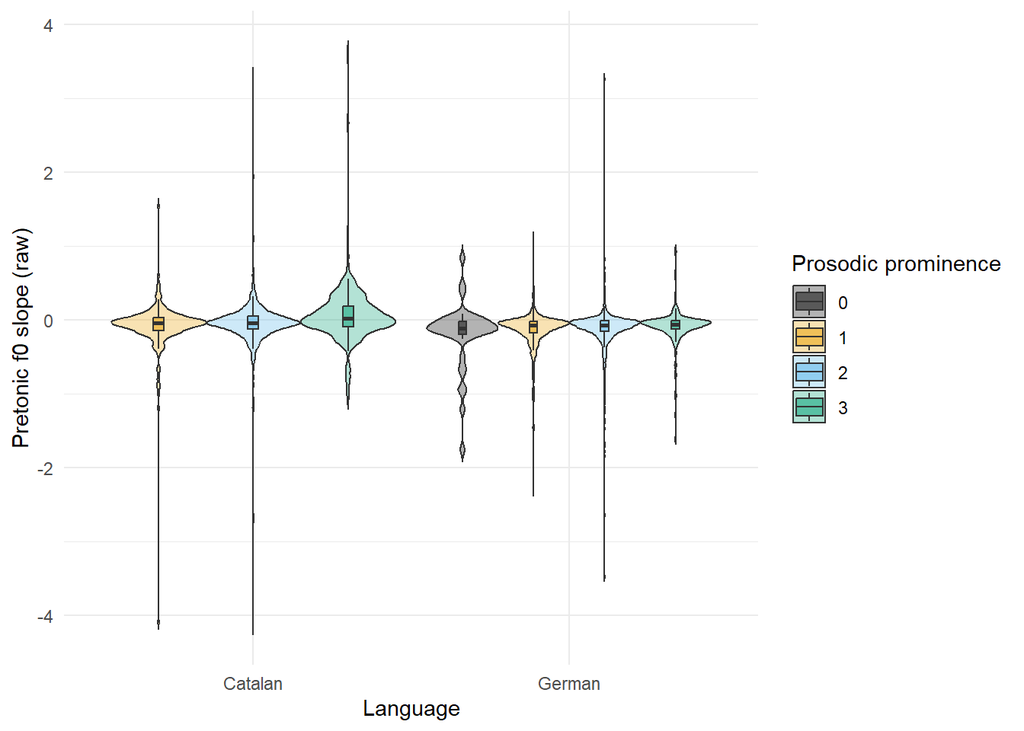

```r
# Plots
## Raw
ggplot(data_prepost %>% filter(!is.na(percProm)), aes(x = language, y = f0_slopePre, fill = as.factor(percProm))) +
  geom_violin(scale = "width", trim = FALSE, alpha = 0.3) +
  geom_boxplot(width = 0.1, outlier.shape = NA, position = position_dodge(width = 0.9), alpha = 0.5) +
  labs(
    #title = "Duration of Prosodic Prominence Ratings by Language",
    x = "Language",
    y = "Pretonic f0 slope (raw)",
    fill = "Prosodic prominence"
  ) +
  scale_fill_manual(values = colorBlindBlack8) +
  theme_minimal()
```

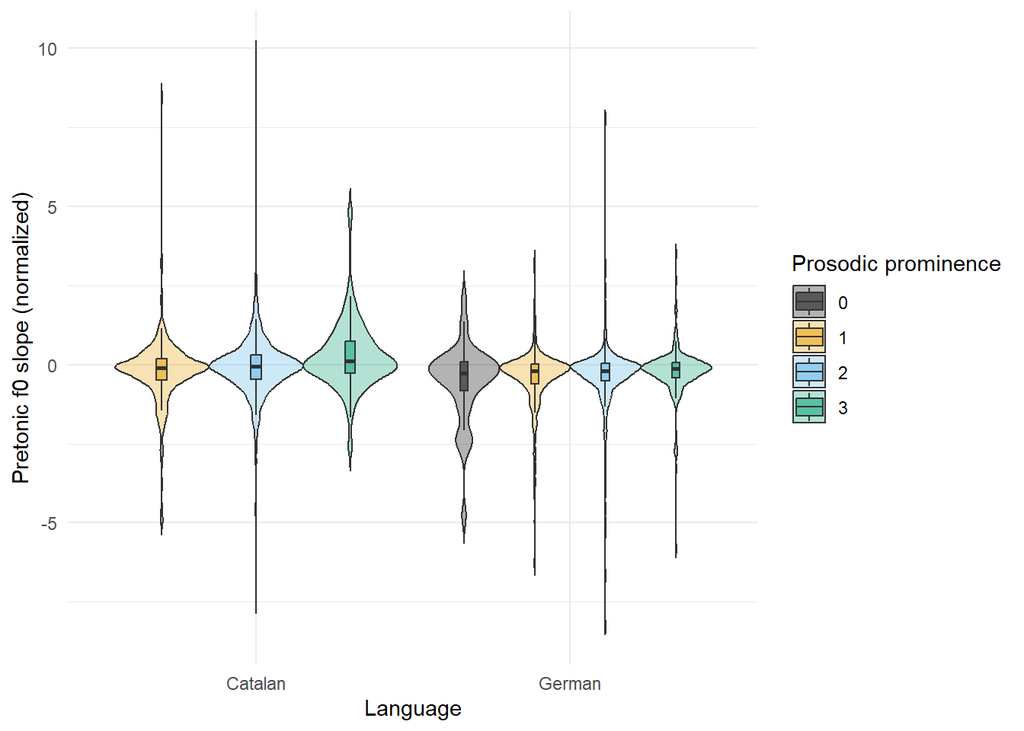

```r
ggsave(filename = paste0(plots, "prominence_f0_slope_raw_pretonic.pdf"), plot = last_plot(), width = 6, height = 4)

## Normalized
ggplot(data_prepost %>% filter(!is.na(percProm)), aes(x = language, y = f0_slope_normPre, fill = as.factor(percProm))) +
  geom_violin(scale = "width", trim = FALSE, alpha = 0.3) +
  geom_boxplot(width = 0.1, outlier.shape = NA, position = position_dodge(width = 0.9), alpha = 0.5) +
  labs(
    #title = "Duration of Prosodic Prominence Ratings by Language",
    x = "Language",
    y = "Pretonic f0 slope (normalized)",
    fill = "Prosodic prominence"
  ) +
  scale_fill_manual(values = colorBlindBlack8) +
  theme_minimal()
```

```r
ggsave(filename = paste0(plots, "prominence_f0_slope_norm_pretonic.pdf"), plot = last_plot(), width = 6, height = 4)
```

#### 3.3.3.9 Spectral centroid (median)

What is the average spectral centeroid (median) across the different prosodic prominence ratings in Catalan vs in German?

```r
# Values
data_prepost %>%
  group_by(language, percProm) %>%
  summarize(avg_specCentroid_median = mean(specCentroid_medianPre, na.rm = TRUE))
```

| language | percProm | avg_specCentroid_median |
| --- | --- | --- |
| Catalan | 1 | 318.5976 |
| Catalan | 2 | 317.8663 |
| Catalan | 3 | 323.4909 |
| German | 0 | 263.7919 |
| German | 1 | 281.6278 |
| German | 2 | 281.9361 |
| German | 3 | 266.1297 |

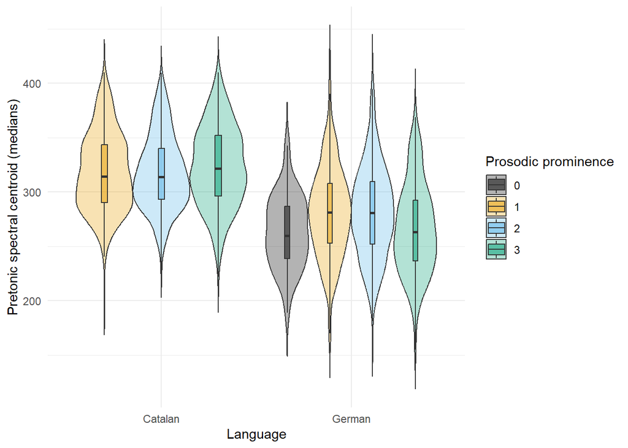

```r
# Plot
ggplot(data_prepost %>% filter(!is.na(percProm)), aes(x = language, y = specCentroid_medianPre, fill = as.factor(percProm))) +
  geom_violin(scale = "width", trim = FALSE, alpha = 0.3) +
  geom_boxplot(width = 0.1, outlier.shape = NA, position = position_dodge(width = 0.9), alpha = 0.5) +
  labs(
    #title = "Duration of Prosodic Prominence Ratings by Language",
    x = "Language",
    y = "Pretonic spectral centroid (medians)",
    fill = "Prosodic prominence"
  ) +
  scale_fill_manual(values = colorBlindBlack8) +
  theme_minimal()
```

```r
ggsave(filename = paste0(plots, "prominence_specCentroid_median_pretonic.pdf"), plot = last_plot(), width = 6, height = 4)
```

#### 3.3.3.10 Entropy (median)

What is the average entropy (median) across the different prosodic prominence ratings in Catalan vs in German?

```r
# Values
data_prepost %>%
  group_by(language, percProm) %>%
  summarize(avg_entropy_median = mean(entropy_medianPre, na.rm = TRUE))
```

| language | percProm | avg_entropy_median |
| --- | --- | --- |
| Catalan | 1 | 0.4380640 |
| Catalan | 2 | 0.3869186 |
| Catalan | 3 | 0.3688181 |
| German | 0 | 0.4793677 |
| German | 1 | 0.4303475 |
| German | 2 | 0.4034003 |
| German | 3 | 0.4162203 |

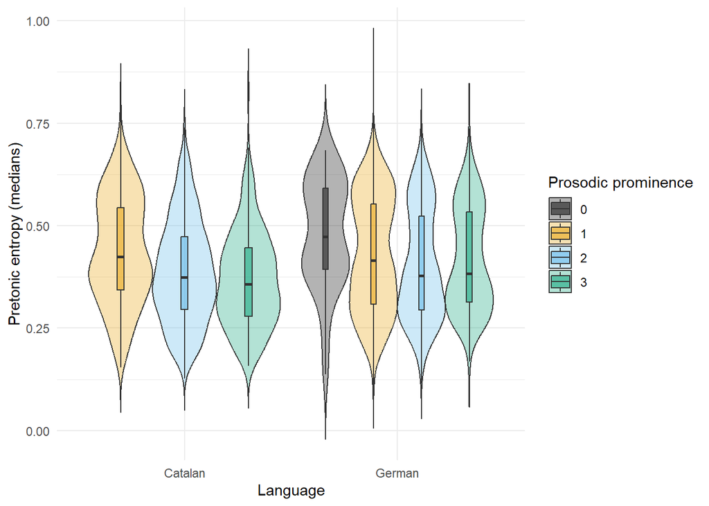

```r
# Plot
ggplot(data_prepost %>% filter(!is.na(percProm)), aes(x = language, y = entropy_medianPre, fill = as.factor(percProm))) +
  geom_violin(scale = "width", trim = FALSE, alpha = 0.3) +
  geom_boxplot(width = 0.1, outlier.shape = NA, position = position_dodge(width = 0.9), alpha = 0.5) +
  labs(
    #title = "Duration of Prosodic Prominence Ratings by Language",
    x = "Language",
    y = "Pretonic entropy (medians)",
    fill = "Prosodic prominence"
  ) +
  scale_fill_manual(values = colorBlindBlack8) +
  theme_minimal()
```

```r
ggsave(filename = paste0(plots, "prominence_entropy_median_pretonic.pdf"), plot = last_plot(), width = 6, height = 4)
```

#### 3.3.3.11 Harmonics-to-Noise Ratio (median)

What is the average Harmonics-to-Noise Ratio (median) across the different prosodic prominence ratings in Catalan vs in German?

```r
# Values
data_prepost %>%
  group_by(language, percProm) %>%
  summarize(avg_HNR_median = mean(HNR_medianPre, na.rm = TRUE))
```

| language | percProm | avg_HNR_median |
| --- | --- | --- |
| Catalan | 1 | 10.497208 |
| Catalan | 2 | 11.236506 |
| Catalan | 3 | 10.872767 |
| German | 0 | 7.832407 |
| German | 1 | 9.128828 |
| German | 2 | 9.910801 |
| German | 3 | 9.848918 |

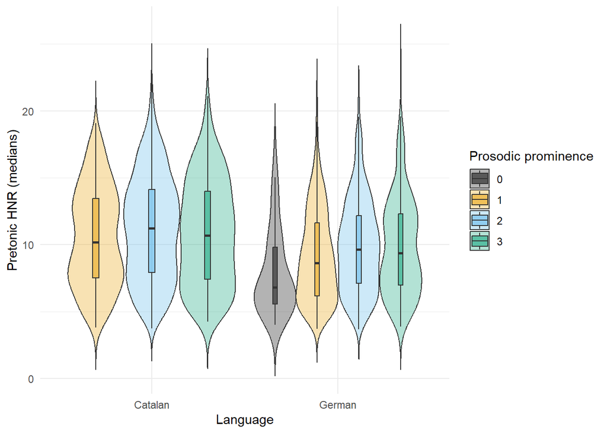

```r
# Plot
ggplot(data_prepost %>% filter(!is.na(percProm)), aes(x = language, y = HNR_medianPre, fill = as.factor(percProm))) +
  geom_violin(scale = "width", trim = FALSE, alpha = 0.3) +
  geom_boxplot(width = 0.1, outlier.shape = NA, position = position_dodge(width = 0.9), alpha = 0.5) +
  labs(
    #title = "Duration of Prosodic Prominence Ratings by Language",
    x = "Language",
    y = "Pretonic HNR (medians)",
    fill = "Prosodic prominence"
  ) +
  scale_fill_manual(values = colorBlindBlack8) +
  theme_minimal()
```

```r
ggsave(filename = paste0(plots, "prominence_HNR_median_pretonic.pdf"), plot = last_plot(), width = 6, height = 4)
```

#### 3.3.3.12 Amplitude modulation (median)

What is the average amplitude modulation (median) across the different prosodic prominence ratings in Catalan vs in German?

```r
# Values
data_prepost %>%
  group_by(language, percProm) %>%
  summarize(avg_amEnvDep_median = mean(amEnvDep_medianPre, na.rm = TRUE))
```

| language | percProm | avg_amEnvDep_median |
| --- | --- | --- |
| Catalan | 1 | 0.9117402 |
| Catalan | 2 | 0.8779541 |
| Catalan | 3 | 0.7122137 |
| German | 0 | 0.9049631 |
| German | 1 | 0.7874699 |
| German | 2 | 0.7259291 |
| German | 3 | 0.6189956 |

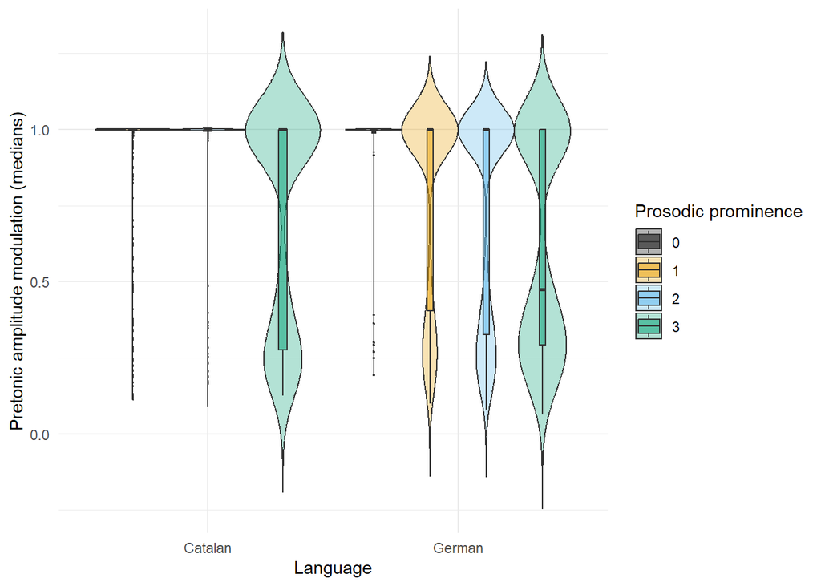

```r
# Plot
ggplot(data_prepost %>% filter(!is.na(percProm)), aes(x = language, y = amEnvDep_medianPre, fill = as.factor(percProm))) +
  geom_violin(scale = "width", trim = FALSE, alpha = 0.3) +
  geom_boxplot(width = 0.1, outlier.shape = NA, position = position_dodge(width = 0.9), alpha = 0.5) +
  labs(
    #title = "Duration of Prosodic Prominence Ratings by Language",
    x = "Language",
    y = "Pretonic amplitude modulation (medians)",
    fill = "Prosodic prominence"
  ) +
  scale_fill_manual(values = colorBlindBlack8) +
  theme_minimal()
```

```r
ggsave(filename = paste0(plots, "prominence_amEnvDep_median_pretonic.pdf"), plot = last_plot(), width = 6, height = 4)
```

#### 3.3.3.13 Frequency modulation (median)

What is the average frequency modulation (median) across the different prosodic prominence ratings in Catalan vs in German?

```r
# Values
data_prepost %>%
  group_by(language, percProm) %>%
  summarize(avg_fmDep_median = mean(fmDep_medianPre, na.rm = TRUE))
```

| language | percProm | avg_fmDep_median |
| --- | --- | --- |
| Catalan | 1 | 0.3628346 |
| Catalan | 2 | 0.3894794 |
| Catalan | 3 | 0.5605495 |
| German | 0 | 0.3527777 |
| German | 1 | 0.3522375 |
| German | 2 | 0.3293018 |
| German | 3 | 0.3651882 |

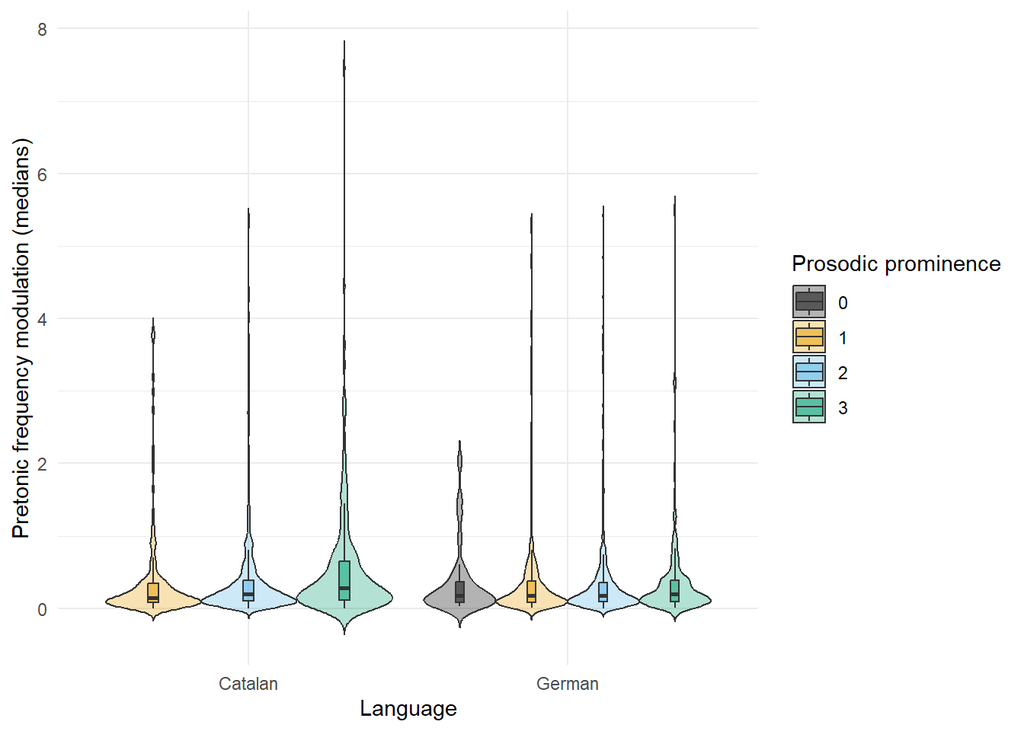

```r
# Plot
ggplot(data_prepost %>% filter(!is.na(percProm)), aes(x = language, y = fmDep_medianPre, fill = as.factor(percProm))) +
  geom_violin(scale = "width", trim = FALSE, alpha = 0.3) +
  geom_boxplot(width = 0.1, outlier.shape = NA, position = position_dodge(width = 0.9), alpha = 0.5) +
  labs(
    #title = "Duration of Prosodic Prominence Ratings by Language",
    x = "Language",
    y = "Pretonic frequency modulation (medians)",
    fill = "Prosodic prominence"
  ) +
  scale_fill_manual(values = colorBlindBlack8) +
  theme_minimal()
```

```r
ggsave(filename = paste0(plots, "prominence_fmDep_median_pretonic.pdf"), plot = last_plot(), width = 6, height = 4)
```

### 3.3.4 Posttonic: Averages prominence

#### 3.3.4.1 Duration

```r
# Values
data_prepost %>%
  group_by(language, percProm) %>%
  summarize(avg_duration = mean(durationPost, na.rm = TRUE))
```

| language | percProm | avg_duration |
| --- | --- | --- |
| Catalan | 1 | 0.1620608 |
| Catalan | 2 | 0.1903050 |
| Catalan | 3 | 0.2117734 |
| German | 0 | 0.2056731 |
| German | 1 | 0.1960906 |
| German | 2 | 0.2140228 |
| German | 3 | 0.2119615 |

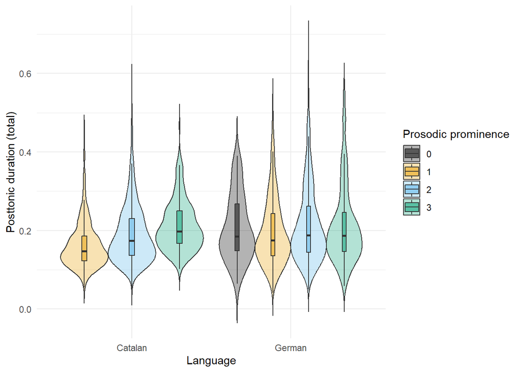

```r
# Plot
ggplot(data_prepost %>% filter(!is.na(percProm)), aes(x = language, y = durationPost, fill = as.factor(percProm))) +
  geom_violin(scale = "width", trim = FALSE, alpha = 0.3) +
  geom_boxplot(width = 0.1, outlier.shape = NA, position = position_dodge(width = 0.9), alpha = 0.5) +
  labs(
    #title = "Duration of Prosodic Prominence Ratings by Language",
    x = "Language",
    y = "Posttonic duration (total)",
    fill = "Prosodic prominence"
  ) +
  scale_fill_manual(values = colorBlindBlack8) +
  theme_minimal()
```

```r
ggsave(filename = paste0(plots, "prominence_duration_posttonic.pdf"), plot = last_plot(), width = 6, height = 4)
```

#### 3.3.4.2 Duration without silences

What is the average duration of sounding across the different prosodic prominence ratings in Catalan vs in German?

```r
# Values
data_prepost %>%
  group_by(language, percProm) %>%
  summarize(avg_duration_noSilence = mean(duration_noSilencePost, na.rm = TRUE))
```

| language | percProm | avg_duration_noSilence |
| --- | --- | --- |
| Catalan | 1 | 0.1538146 |
| Catalan | 2 | 0.1807518 |
| Catalan | 3 | 0.2025391 |
| German | 0 | 0.1923077 |
| German | 1 | 0.1860361 |
| German | 2 | 0.2034928 |
| German | 3 | 0.2008462 |

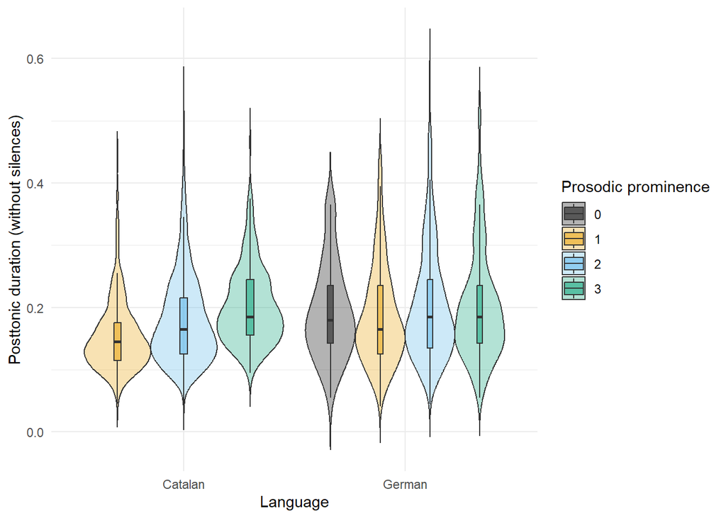

```r
# Plot
ggplot(data_prepost %>% filter(!is.na(percProm)), aes(x = language, y = duration_noSilencePost, fill = as.factor(percProm))) +
  geom_violin(scale = "width", trim = FALSE, alpha = 0.3) +
  geom_boxplot(width = 0.1, outlier.shape = NA, position = position_dodge(width = 0.9), alpha = 0.5) +
  labs(
    #title = "Duration of Prosodic Prominence Ratings by Language",
    x = "Language",
    y = "Posttonic duration (without silences)",
    fill = "Prosodic prominence"
  ) +
  scale_fill_manual(values = colorBlindBlack8) +
  theme_minimal()
```

```r
ggsave(filename = paste0(plots, "prominence_duration_noSilence_posttonic.pdf"), plot = last_plot(), width = 6, height = 4)
```

#### 3.3.4.3 Amplitude (median)

What is the average amplitude (median) across the different prosodic prominence ratings in Catalan vs in German?

```r
# Values
data_prepost %>%
  group_by(language, percProm) %>%
  summarize(avg_ampl_median = mean(ampl_medianPost, na.rm = TRUE))
```

| language | percProm | avg_ampl_median |
| --- | --- | --- |
| Catalan | 1 | 0.07636534 |
| Catalan | 2 | 0.10923239 |
| Catalan | 3 | 0.07999749 |
| German | 0 | 0.01157661 |
| German | 1 | 0.02204213 |
| German | 2 | 0.03338509 |
| German | 3 | 0.04277130 |

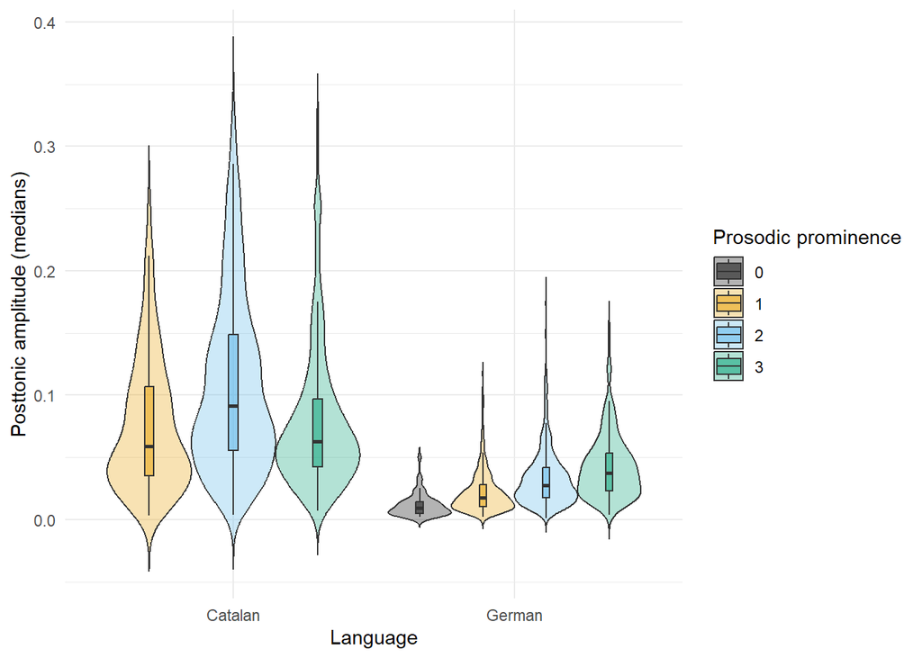

```r
# Plot
ggplot(data_prepost %>% filter(!is.na(percProm)), aes(x = language, y = ampl_medianPost, fill = as.factor(percProm))) +
  geom_violin(scale = "width", trim = FALSE, alpha = 0.3) +
  geom_boxplot(width = 0.1, outlier.shape = NA, position = position_dodge(width = 0.9), alpha = 0.5) +
  labs(
    #title = "Duration of Prosodic Prominence Ratings by Language",
    x = "Language",
    y = "Posttonic amplitude (medians)",
    fill = "Prosodic prominence"
  ) +
  scale_fill_manual(values = colorBlindBlack8) +
  theme_minimal()
```

```r
ggsave(filename = paste0(plots, "prominence_ampl_median_posttonic.pdf"), plot = last_plot(), width = 6, height = 4)
```

#### 3.3.4.4 Amplitude (median) without silences

What is the average amplitude (median) without silences across the different prosodic prominence ratings in Catalan vs in German?

```r
# Values
data_prepost %>%
  group_by(language, percProm) %>%
  summarize(avg_ampl_noSilence_median = mean(ampl_noSilence_medianPost, na.rm = TRUE))
```

| language | percProm | avg_ampl_noSilence_median |
| --- | --- | --- |
| Catalan | 1 | 0.07914130 |
| Catalan | 2 | 0.11320653 |
| Catalan | 3 | 0.08232305 |
| German | 0 | 0.01190043 |
| German | 1 | 0.02237960 |
| German | 2 | 0.03390964 |
| German | 3 | 0.04339430 |

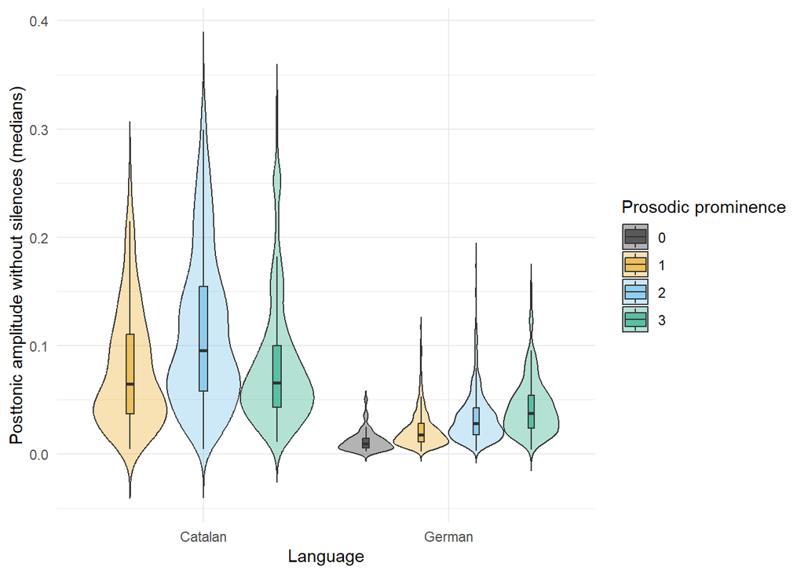

```r
# Plot
ggplot(data_prepost %>% filter(!is.na(percProm)), aes(x = language, y = ampl_noSilence_medianPost, fill = as.factor(percProm))) +
  geom_violin(scale = "width", trim = FALSE, alpha = 0.3) +
  geom_boxplot(width = 0.1, outlier.shape = NA, position = position_dodge(width = 0.9), alpha = 0.5) +
  labs(
    #title = "Duration of Prosodic Prominence Ratings by Language",
    x = "Language",
    y = "Posttonic amplitude without silences (medians)",
    fill = "Prosodic prominence"
  ) +
  scale_fill_manual(values = colorBlindBlack8) +
  theme_minimal()
```

```r
ggsave(filename = paste0(plots, "prominence_ampl_noSilence_median_posttonic.pdf"), plot = last_plot(), width = 6, height = 4)
```

#### 3.3.4.5 Amplitude envelope slope

What is the average amplitude envelope slope across the different prosodic prominence ratings in Catalan vs in German?

```r
# Values
data_prepost %>%
  group_by(language, percProm) %>%
  summarize(avg_env_slope = mean(env_slopePost, na.rm = TRUE))
```

| language | percProm | avg_env_slope |
| --- | --- | --- |
| Catalan | 1 | -2.423633e-04 |
| Catalan | 2 | -1.738037e-04 |
| Catalan | 3 | -3.556011e-04 |
| German | 0 | -3.964123e-06 |
| German | 1 | -4.669447e-05 |
| German | 2 | -7.413380e-05 |
| German | 3 | -1.736177e-04 |

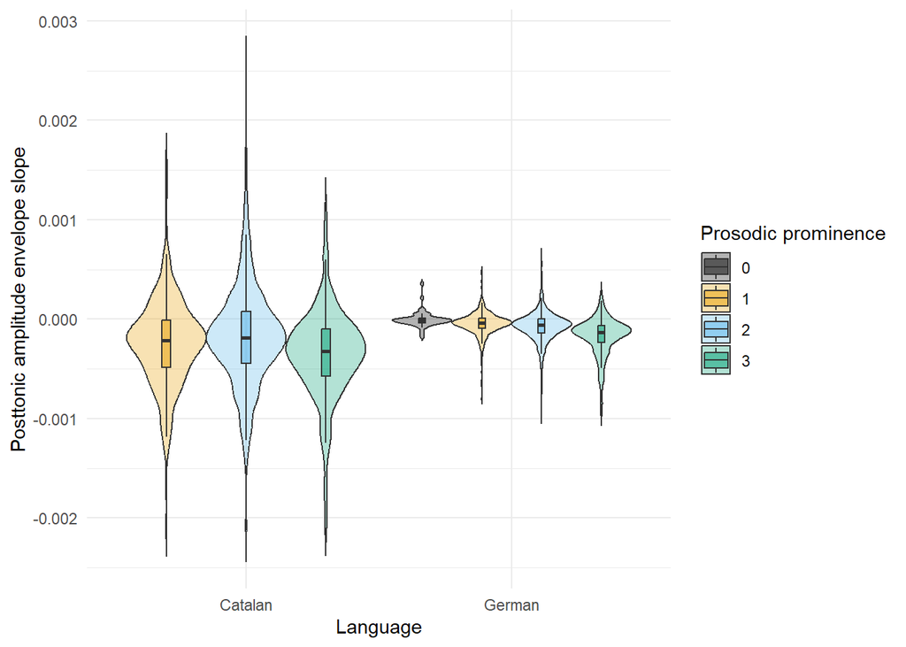

```r
# Plot
ggplot(data_prepost %>% filter(!is.na(percProm)), aes(x = language, y = env_slopePost, fill = as.factor(percProm))) +
  geom_violin(scale = "width", trim = FALSE, alpha = 0.3) +
  geom_boxplot(width = 0.1, outlier.shape = NA, position = position_dodge(width = 0.9), alpha = 0.5) +
  labs(
    x = "Language",
    y = "Posttonic amplitude envelope slope",
    fill = "Prosodic prominence"
  ) +
  scale_fill_manual(values = colorBlindBlack8) +
  theme_minimal()
```

```r
ggsave(filename = paste0(plots, "prominence_env_slope_posttonic.pdf"), plot = last_plot(), width = 6, height = 4)
```

#### 3.3.4.6 Pitch (median)

What is the average pitch (median) across the different prosodic prominence ratings in Catalan vs in German?

```r
#Vavlues
## Raw
avg_pitch_median_pre <- data_prepost %>%
  group_by(language, percProm) %>%
  summarize(avg_pitch_median = mean(pitch_medianPost, na.rm = TRUE))

## Normalized
data_prepost %>%
  group_by(language, percProm) %>%
  summarize(avg_pitch_median_norm = mean(pitch_median_normPost, na.rm = TRUE))
```

| language | percProm | avg_pitch_median_norm |
| --- | --- | --- |
| Catalan | 1 | -0.1198186 |
| Catalan | 2 | 0.1696992 |
| Catalan | 3 | -0.1583666 |
| German | 0 | -0.1112949 |
| German | 1 | -0.2720261 |
| German | 2 | 0.3054532 |
| German | 3 | 0.2561438 |

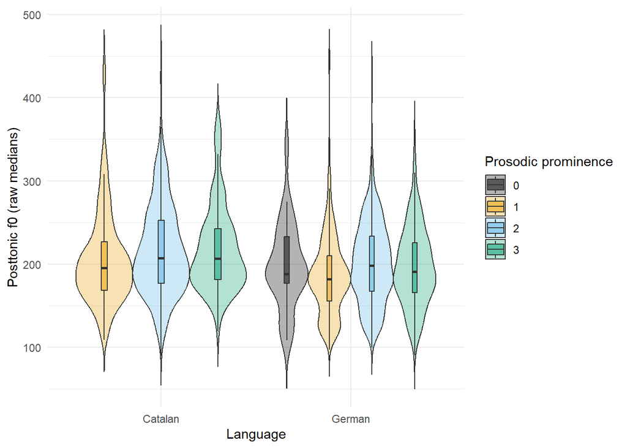

```r
# Plots
## Raw
ggplot(data_prepost %>% filter(!is.na(percProm)), aes(x = language, y = pitch_medianPost, fill = as.factor(percProm))) +
  geom_violin(scale = "width", trim = FALSE, alpha = 0.3) +
  geom_boxplot(width = 0.1, outlier.shape = NA, position = position_dodge(width = 0.9), alpha = 0.5) +
  labs(
    x = "Language",
    y = "Posttonic f0 (raw medians)",
    fill = "Prosodic prominence"
  ) +
  scale_fill_manual(values = colorBlindBlack8) +
  theme_minimal()
```

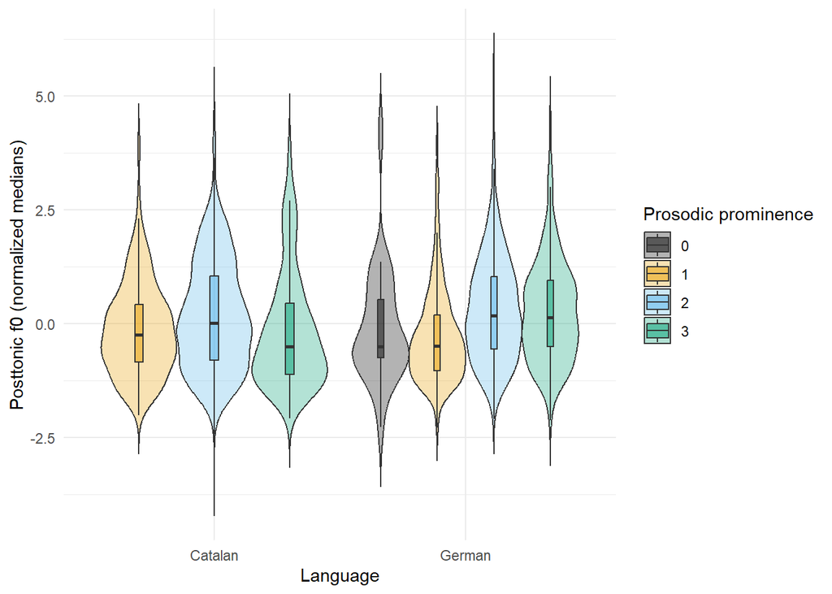

```r
ggsave(filename = paste0(plots, "prominence_pitch_median_raw_posttonic.pdf"), plot = last_plot(), width = 6, height = 4)

## Normalized
ggplot(data_prepost %>% filter(!is.na(percProm)), aes(x = language, y = pitch_median_normPost, fill = as.factor(percProm))) +
  geom_violin(scale = "width", trim = FALSE, alpha = 0.3) +
  geom_boxplot(width = 0.1, outlier.shape = NA, position = position_dodge(width = 0.9), alpha = 0.5) +
  labs(
    x = "Language",
    y = "Posttonic f0 (normalized medians)",
    fill = "Prosodic prominence"
  ) +
  scale_fill_manual(values = colorBlindBlack8) +
  theme_minimal()
```

```r
ggsave(filename = paste0(plots, "prominence_pitch_median_norm_posttonic.pdf"), plot = last_plot(), width = 6, height = 4)
```

#### 3.3.4.7 Pitch (sd)

What is the average pitch (sd) across the different prosodic prominence ratings in Catalan vs in German?

```r
# Values
## Raw
data_prepost %>%
  group_by(language, percProm) %>%
  summarize(avg_pitch_sd = mean(pitch_sdPost, na.rm = TRUE))
```

| language | percProm | avg_pitch_sd |
| --- | --- | --- |
| Catalan | 1 | 11.79447 |
| Catalan | 2 | 13.18741 |
| Catalan | 3 | 16.44995 |
| German | 0 | 12.94663 |
| German | 1 | 10.12299 |
| German | 2 | 11.30969 |
| German | 3 | 14.71927 |

```r
## Normalized
data_prepost %>%
  group_by(language, percProm) %>%
  summarize(avg_pitch_sd = mean(pitch_sd_normPost, na.rm = TRUE))
```

| language | percProm | avg_pitch_sd |
| --- | --- | --- |
| Catalan | 1 | 0.004223173 |
| Catalan | 2 | 0.124675686 |
| Catalan | 3 | 0.217770390 |
| German | 0 | 0.058653163 |
| German | 1 | -0.198070598 |
| German | 2 | -0.034007248 |
| German | 3 | 0.194892577 |

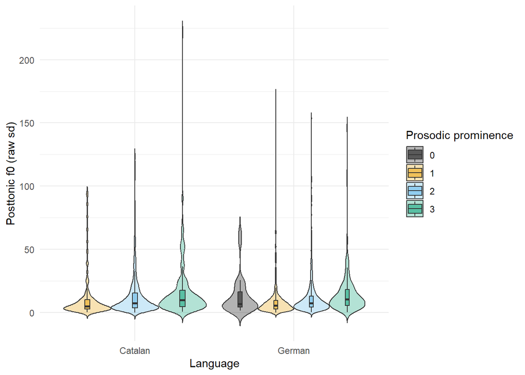

```r
# Plots
## Raw
ggplot(data_prepost %>% filter(!is.na(percProm)), aes(x = language, y = pitch_sdPost, fill = as.factor(percProm))) +
  geom_violin(scale = "width", trim = FALSE, alpha = 0.3) +
  geom_boxplot(width = 0.1, outlier.shape = NA, position = position_dodge(width = 0.9), alpha = 0.5) +
  labs(
    #title = "Duration of Prosodic Prominence Ratings by Language",
    x = "Language",
    y = "Posttonic f0 (raw sd)",
    fill = "Prosodic prominence"
  ) +
  scale_fill_manual(values = colorBlindBlack8) +
  theme_minimal()
```

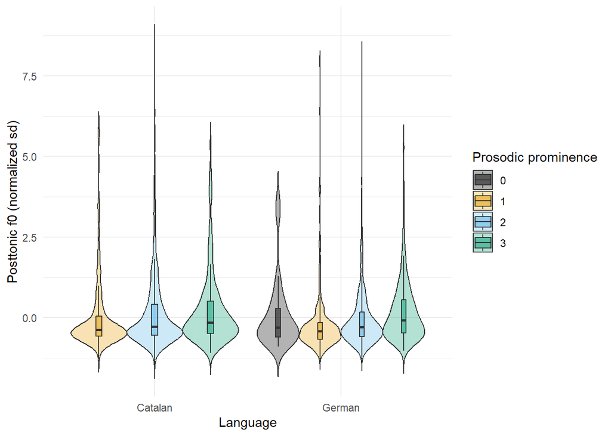

```r
ggsave(filename = paste0(plots, "prominence_pitch_sd_raw_posttonic.pdf"), plot = last_plot(), width = 6, height = 4)

## Normalized
ggplot(data_prepost %>% filter(!is.na(percProm)), aes(x = language, y = pitch_sd_normPost, fill = as.factor(percProm))) +
  geom_violin(scale = "width", trim = FALSE, alpha = 0.3) +
  geom_boxplot(width = 0.1, outlier.shape = NA, position = position_dodge(width = 0.9), alpha = 0.5) +
  labs(
    #title = "Duration of Prosodic Prominence Ratings by Language",
    x = "Language",
    y = "Posttonic f0 (normalized sd)",
    fill = "Prosodic prominence"
  ) +
  scale_fill_manual(values = colorBlindBlack8) +
  theme_minimal()
```

```r
ggsave(filename = paste0(plots, "prominence_pitch_sd_norm_posttonic.pdf"), plot = last_plot(), width = 6, height = 4)
```

#### 3.3.4.8 F0 slope

What is the average f0 slope across the different prosodic prominence ratings in Catalan vs in German?

```r
#Values
## Raw
data_prepost %>%
  group_by(language, percProm) %>%
  summarize(avg_f0_slope = mean(f0_slopePost, na.rm = TRUE))
```

| language | percProm | avg_f0_slope |
| --- | --- | --- |
| Catalan | 1 | 0.02205775 |
| Catalan | 2 | 0.05646742 |
| Catalan | 3 | -0.10105694 |
| German | 0 | -0.04013283 |
| German | 1 | -0.08161458 |
| German | 2 | -0.10315591 |
| German | 3 | -0.22663000 |

```r
## Normalized
data_prepost %>%
  group_by(language, percProm) %>%
  summarize(avg_f0_slope = mean(f0_slope_normPost, na.rm = TRUE))
```

| language | percProm | avg_f0_slope |
| --- | --- | --- |
| Catalan | 1 | 0.1317089375 |
| Catalan | 2 | 0.3263536847 |
| Catalan | 3 | -0.3104629752 |
| German | 0 | -0.0004090172 |
| German | 1 | -0.2278057448 |
| German | 2 | -0.2968971281 |
| German | 3 | -0.7534347882 |

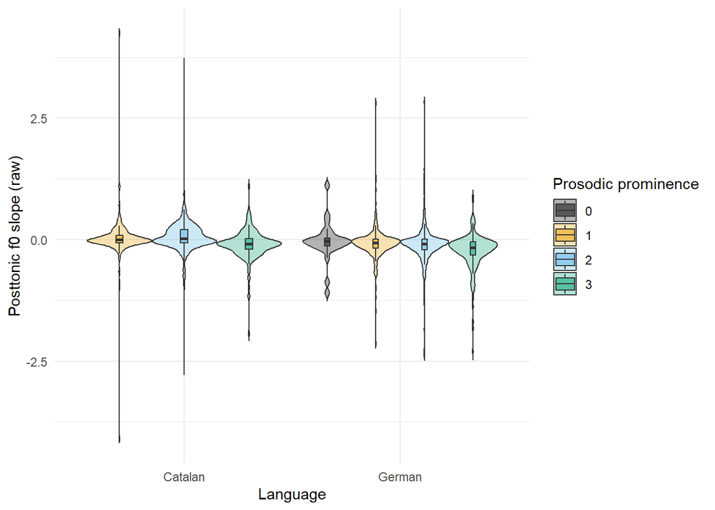

```r
# Plots
## Raw
ggplot(data_prepost %>% filter(!is.na(percProm)), aes(x = language, y = f0_slopePost, fill = as.factor(percProm))) +
  geom_violin(scale = "width", trim = FALSE, alpha = 0.3) +
  geom_boxplot(width = 0.1, outlier.shape = NA, position = position_dodge(width = 0.9), alpha = 0.5) +
  labs(
    #title = "Duration of Prosodic Prominence Ratings by Language",
    x = "Language",
    y = "Posttonic f0 slope (raw)",
    fill = "Prosodic prominence"
  ) +
  scale_fill_manual(values = colorBlindBlack8) +
  theme_minimal()
```

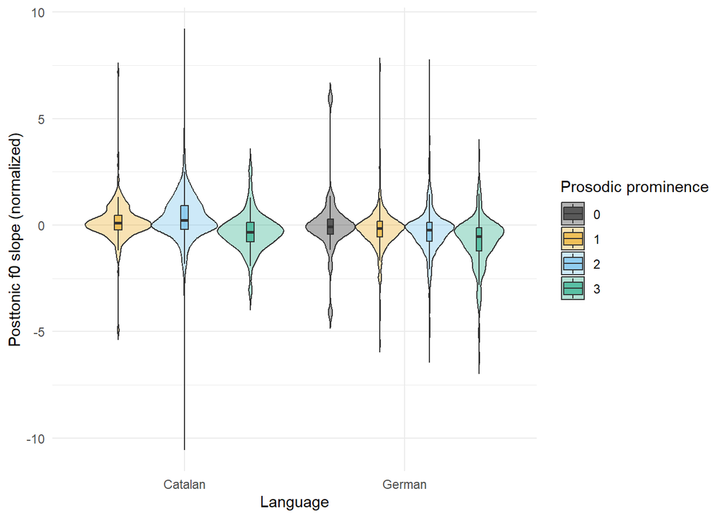

```r
ggsave(filename = paste0(plots, "prominence_f0_slope_raw_posttonic.pdf"), plot = last_plot(), width = 6, height = 4)

## Normalized
ggplot(data_prepost %>% filter(!is.na(percProm)), aes(x = language, y = f0_slope_normPost, fill = as.factor(percProm))) +
  geom_violin(scale = "width", trim = FALSE, alpha = 0.3) +
  geom_boxplot(width = 0.1, outlier.shape = NA, position = position_dodge(width = 0.9), alpha = 0.5) +
  labs(
    #title = "Duration of Prosodic Prominence Ratings by Language",
    x = "Language",
    y = "Posttonic f0 slope (normalized)",
    fill = "Prosodic prominence"
  ) +
  scale_fill_manual(values = colorBlindBlack8) +
  theme_minimal()
```

```r
ggsave(filename = paste0(plots, "prominence_f0_slope_norm_posttonic.pdf"), plot = last_plot(), width = 6, height = 4)
```

#### 3.3.4.9 Spectral centroid (median)

What is the average spectral centeroid (median) across the different prosodic prominence ratings in Catalan vs in German?

```r
# Values
data_prepost %>%
  group_by(language, percProm) %>%
  summarize(avg_specCentroid_median = mean(specCentroid_medianPost, na.rm = TRUE))
```

| language | percProm | avg_specCentroid_median |
| --- | --- | --- |
| Catalan | 1 | 299.7294 |
| Catalan | 2 | 308.3747 |
| Catalan | 3 | 306.4197 |
| German | 0 | 281.2425 |
| German | 1 | 283.5134 |
| German | 2 | 293.5557 |
| German | 3 | 286.9244 |

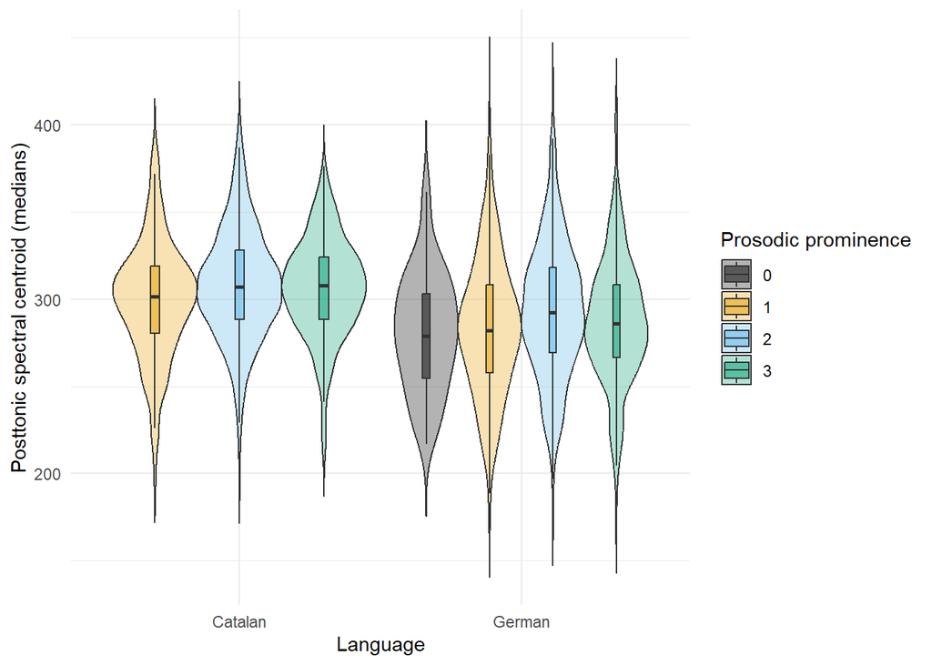

```r
# Plot
ggplot(data_prepost %>% filter(!is.na(percProm)), aes(x = language, y = specCentroid_medianPost, fill = as.factor(percProm))) +
  geom_violin(scale = "width", trim = FALSE, alpha = 0.3) +
  geom_boxplot(width = 0.1, outlier.shape = NA, position = position_dodge(width = 0.9), alpha = 0.5) +
  labs(
    #title = "Duration of Prosodic Prominence Ratings by Language",
    x = "Language",
    y = "Posttonic spectral centroid (medians)",
    fill = "Prosodic prominence"
  ) +
  scale_fill_manual(values = colorBlindBlack8) +
  theme_minimal()
```

```r
ggsave(filename = paste0(plots, "prominence_specCentroid_median_posttonic.pdf"), plot = last_plot(), width = 6, height = 4)
```

#### 3.3.4.10 Entropy (median)

What is the average entropy (median) across the different prosodic prominence ratings in Catalan vs in German?

```r
# Values
data_prepost %>%
  group_by(language, percProm) %>%
  summarize(avg_entropy_median = mean(entropy_medianPost, na.rm = TRUE))
```

| language | percProm | avg_entropy_median |
| --- | --- | --- |
| Catalan | 1 | 0.4919111 |
| Catalan | 2 | 0.4174613 |
| Catalan | 3 | 0.4606919 |
| German | 0 | 0.5140917 |
| German | 1 | 0.4752888 |
| German | 2 | 0.3986162 |
| German | 3 | 0.4285122 |

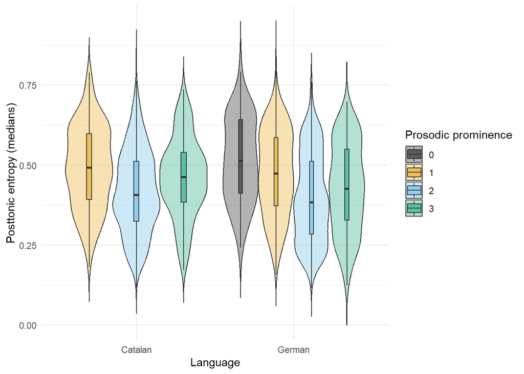

```r
# Plot
ggplot(data_prepost %>% filter(!is.na(percProm)), aes(x = language, y = entropy_medianPost, fill = as.factor(percProm))) +
  geom_violin(scale = "width", trim = FALSE, alpha = 0.3) +
  geom_boxplot(width = 0.1, outlier.shape = NA, position = position_dodge(width = 0.9), alpha = 0.5) +
  labs(
    #title = "Duration of Prosodic Prominence Ratings by Language",
    x = "Language",
    y = "Posttonic entropy (medians)",
    fill = "Prosodic prominence"
  ) +
  scale_fill_manual(values = colorBlindBlack8) +
  theme_minimal()
```

```r
ggsave(filename = paste0(plots, "prominence_entropy_median_posttonic.pdf"), plot = last_plot(), width = 6, height = 4)
```

#### 3.3.4.11 Harmonics-to-Noise Ratio (median)

What is the average Harmonics-to-Noise Ratio (median) across the different prosodic prominence ratings in Catalan vs in German?

```r
# Values
data_prepost %>%
  group_by(language, percProm) %>%
  summarize(avg_HNR_median = mean(HNR_medianPost, na.rm = TRUE))
```

| language | percProm | avg_HNR_median |
| --- | --- | --- |
| Catalan | 1 | 9.307026 |
| Catalan | 2 | 10.283903 |
| Catalan | 3 | 9.049578 |
| German | 0 | 7.288860 |
| German | 1 | 8.121249 |
| German | 2 | 9.307022 |
| German | 3 | 8.576676 |

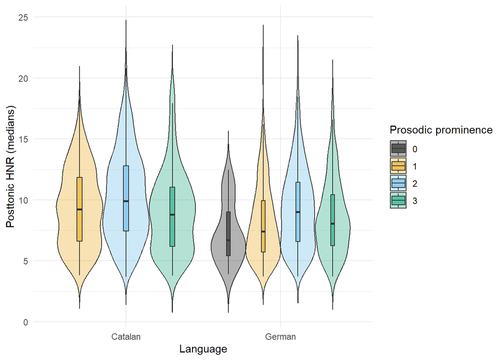

```r
# Plot
ggplot(data_prepost %>% filter(!is.na(percProm)), aes(x = language, y = HNR_medianPost, fill = as.factor(percProm))) +
  geom_violin(scale = "width", trim = FALSE, alpha = 0.3) +
  geom_boxplot(width = 0.1, outlier.shape = NA, position = position_dodge(width = 0.9), alpha = 0.5) +
  labs(
    #title = "Duration of Prosodic Prominence Ratings by Language",
    x = "Language",
    y = "Posttonic HNR (medians)",
    fill = "Prosodic prominence"
  ) +
  scale_fill_manual(values = colorBlindBlack8) +
  theme_minimal()
```

```r
ggsave(filename = paste0(plots, "prominence_HNR_median_posttonic.pdf"), plot = last_plot(), width = 6, height = 4)
```

#### 3.3.4.12 Amplitude modulation (median)

What is the average amplitude modulation (median) across the different prosodic prominence ratings in Catalan vs in German?

```r
# Values
data_prepost %>%
  group_by(language, percProm) %>%
  summarize(avg_amEnvDep_median = mean(amEnvDep_medianPost, na.rm = TRUE))
```

| language | percProm | avg_amEnvDep_median |
| --- | --- | --- |
| Catalan | 1 | 0.8694964 |
| Catalan | 2 | 0.7657331 |
| Catalan | 3 | 0.6859584 |
| German | 0 | 0.6941394 |
| German | 1 | 0.7436353 |
| German | 2 | 0.6941151 |
| German | 3 | 0.7004963 |

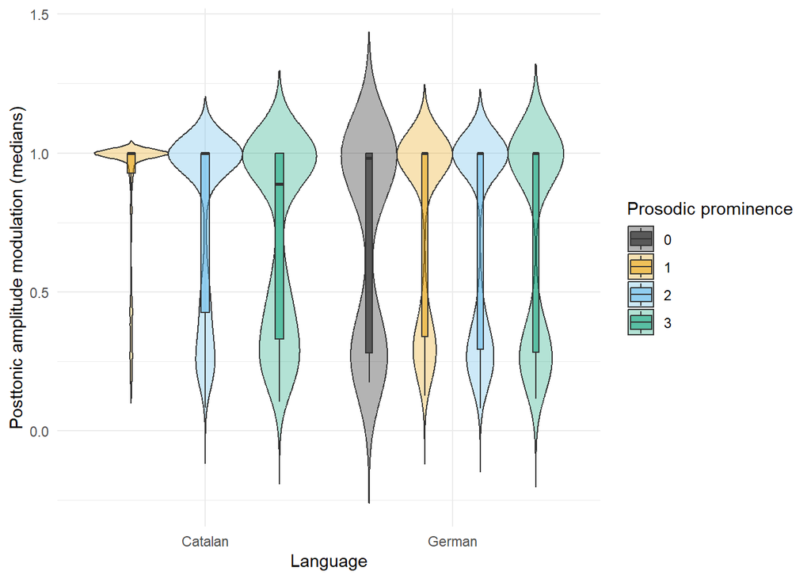

```r
# Plot
ggplot(data_prepost %>% filter(!is.na(percProm)), aes(x = language, y = amEnvDep_medianPost, fill = as.factor(percProm))) +
  geom_violin(scale = "width", trim = FALSE, alpha = 0.3) +
  geom_boxplot(width = 0.1, outlier.shape = NA, position = position_dodge(width = 0.9), alpha = 0.5) +
  labs(
    #title = "Duration of Prosodic Prominence Ratings by Language",
    x = "Language",
    y = "Posttonic amplitude modulation (medians)",
    fill = "Prosodic prominence"
  ) +
  scale_fill_manual(values = colorBlindBlack8) +
  theme_minimal()
```

```r
ggsave(filename = paste0(plots, "prominence_amEnvDep_median_posttonic.pdf"), plot = last_plot(), width = 6, height = 4)
```

#### 3.3.4.13 Frequency modulation (median)

What is the average frequency modulation (median) across the different prosodic prominence ratings in Catalan vs in German?

```r
# Values
data_prepost %>%
  group_by(language, percProm) %>%
  summarize(avg_fmDep_median = mean(fmDep_medianPost, na.rm = TRUE))
```

| language | percProm | avg_fmDep_median |
| --- | --- | --- |
| Catalan | 1 | 0.4421848 |
| Catalan | 2 | 0.4327798 |
| Catalan | 3 | 0.5207636 |
| German | 0 | 0.4376965 |
| German | 1 | 0.3522476 |
| German | 2 | 0.4290786 |
| German | 3 | 0.4935698 |

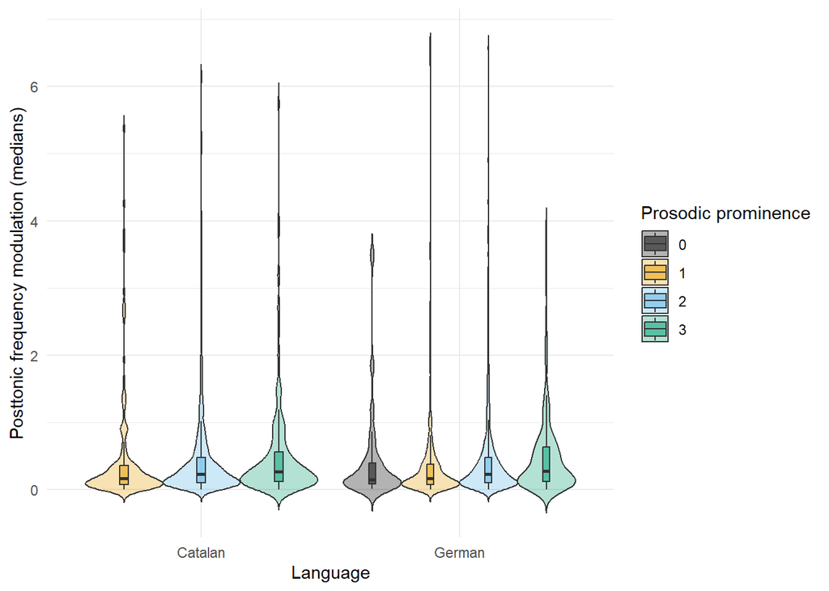

```r
# Plot
ggplot(data_prepost %>% filter(!is.na(percProm)), aes(x = language, y = fmDep_medianPost, fill = as.factor(percProm))) +
  geom_violin(scale = "width", trim = FALSE, alpha = 0.3) +
  geom_boxplot(width = 0.1, outlier.shape = NA, position = position_dodge(width = 0.9), alpha = 0.5) +
  labs(
    #title = "Duration of Prosodic Prominence Ratings by Language",
    x = "Language",
    y = "Posttonic frequency modulation (medians)",
    fill = "Prosodic prominence"
  ) +
  scale_fill_manual(values = colorBlindBlack8) +
  theme_minimal()
```

```r
ggsave(filename = paste0(plots, "prominence_fmDep_median_posttonic.pdf"), plot = last_plot(), width = 6, height = 4)
```